# Analiza Szeregów Czasowych zadanie 3

2025-11-17

```r
library(ggplot2)
library(patchwork)
library(dplyr)
library(RColorBrewer)
set.seed(123)
```

```r
my_cols <- my_cols <- brewer.pal(5, "Set2")
```

# Zadanie 3

## a)

### Esymator średniej

Niech $x_1,x_2,...,x_n$ będzie realizacją szeregu czasowego. Estymator wartości średniej $\mu_X$ definiujemy jako:

$\bar{x} = \frac{1}{n}\sum_{t = 1}^{n}x_t$

```r
mn <- function(data){
  return (mean(data))
}
```

### Autokowariancja próbkowa

Próbkową funkcję autokowariancji definiujemy jako $\hat{\gamma}(h) = \frac{1}{n} \sum_{t=1}^{n-|h|}(x_{t+|h|}-\overline{x})(x_t-\overline{x})$ -n<h<n

```r
ACVF <- function(data,h){



  x_bar = mn(data)

  result = 0

  n = length(data)

  if( abs(h) > n){
    stop("h must be greater than -n and lower than n")
  }

  for (t in 1:(n-abs(h))){
    result  = result + (data[t + abs(h)]-x_bar) * (data[t] - x_bar)
  }
  result = result / n
  return (result)
}
```

Próbkową funkcję autokroelacji definiujemy, jako

$\hat{\rho}(h) = \frac{\hat{\gamma}(h)}{\hat{\gamma}(0)}$, -n<h<n

```r
ACF <- function(data,h){

  n = length(data)

  if( abs(h) > n){
    stop("h must be greater than -n and lower than n")
  }

  part1 = ACVF(data,h)

  part2 = ACVF(data,0)

  result = part1/part2

  return (result)

}
```

### Reguła indentyfikacji modelu $WN(0,\sigma^2)$

Szereg możemy uznać za realizację białego szumu jeżeli:

### Definicja funkcji rysującej wykres ACF

```r
ggplot_ACF <- function(data, max_lag = length(data)-1, ci = TRUE) {
  col = my_cols[3]

  n <- length(data)
  lags <- 1:max_lag

  acf_vals <- sapply(lags, function(h) ACF(data, h))

  df2 <- data.frame(
    lag = lags,
    acf = acf_vals
  )

  df1 = data.frame(
    y = data,
    t = 1:length(data)
  )

  p1 <- ggplot(df1,aes(x = t, y = y)) +
    geom_line(color = col)+
    geom_point(alpha = 0.5,color = col)+
    theme_minimal()+
    labs(y = expression(Y[t]), x = expression(t), title =  expression("Wykres liniowy danych"))


  p2 <- ggplot(df2, aes(x = lag, y = acf)) +
    geom_hline(yintercept = 0) +
    geom_point(alpha = 0.5,color = col)+
    geom_segment(aes(xend = lag, y = 0, yend = acf), linewidth = 0.8,color = col) +
    labs(x = "Lag", y = "ACF", title = "Wykres ACF") +
    theme_minimal()

  df3 = data.frame(
    t_1 = data[1 : (length(data)-1)],
    t = data[2: length(data)]
  )

  p3 = ggplot(df3,aes(x = t_1,y = t))+
                 geom_point(color = col)+
                  theme_minimal()+
                   labs(y = expression(Y[t]), x = expression(Y[t-1]), title =  expression("Zależność" ~ Y[t] ~ " od " ~ Y[t-1]))

  if (ci) {
    ci_lim <- 1.96 / sqrt(n)
    p2 <- p2 +
      geom_hline(yintercept = c(-ci_lim, ci_lim),
                 linetype = "dashed",color = "red",lwd = 0.75)
  }

  p1 / (p2 | p3)

}

# example usage:
# ggplot_ACF(your_ts_vector, max_lag = 40)
```

```r
x_white <- rnorm(20)  # 200 iid N(0,1)
print(x_white)
```

```
##  [1] -0.56047565 -0.23017749  1.55870831  0.07050839  0.12928774  1.71506499
##  [7]  0.46091621 -1.26506123 -0.68685285 -0.44566197  1.22408180  0.35981383
## [13]  0.40077145  0.11068272 -0.55584113  1.78691314  0.49785048 -1.96661716
## [19]  0.70135590 -0.47279141
```

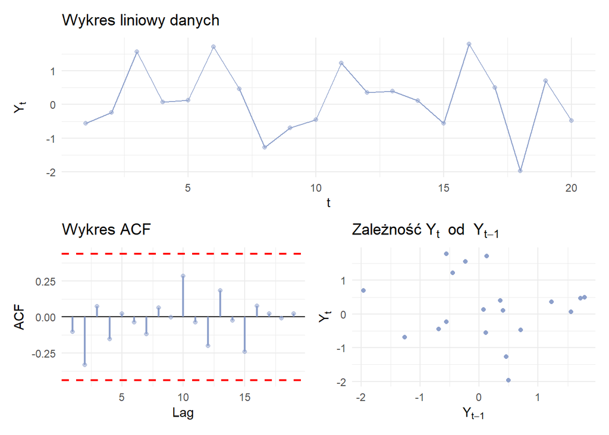

```r
ggplot_ACF(x_white)
```

### Własności asymptotyczne estymatorów średniej autokowariancji i autokorelacji

Jeżeli {$X_t$} jest procesem stacjonarnym, wówczas biorąc pod uwagę własnośći drugiego rzędu jest on scharakteryzowany przez średnią $\mu$ oraz funckję autokowariancji $\gamma(\cdot)$

Estymacja $\mu , \gamma(\cdot)$ oraz funkcji autokorelacji $\theta(\cdot) = \frac{\gamma(\cdot)}{\gamma(0)}$ na podstawie obserwacji $X_1,X_2,X_3,...,X_n$ odgrywa kluczową rolę dla metod wnioskowania statystycznego, w szczególności w przypadku dopasowania odpowiedniego modelu dla danych i konstrukcji optymalnych prognoz

Ważne jest aby wykorzystane estymatory $\hat{\mu},\hat{\gamma(\cdot)} i \theta(\cdot)$ charakteryzowały się odpowiednimi własnościami asymptotycznymi

## Reguła graficznej identyfikacji białego szumu$

Szereg możemy uznać za realizację białego szumu jeżeli:

1. Co najmniej 95% autokorelacji próbkowych $(ACF(h), h = 1,2,...,h_{max})$ znajduje się w przedziale ufności : $\frac{\pm{1,96}}{\sqrt{n}}$
2. Nie powinno być autokorelacji “istotnie” wychodzących pzoa przedziały ufności $\frac{\pm{1,96}}{\sqrt{n}}$

## Formalne testy białoszumowości oparte na ACF

1. Podstawowe testy oparte na ACF
   1. text Boxa-Pierce’a
   2. test Ljungi-Boxa
2. Idea obu testów jest następująca: zamiast sprawdzać (tak jak w graficznym teście białoszumowości) dla każdego h = 1,2,3,… czy autokorelacja próbkowa ACF(h) znajduje się pomiędzy przedziałami istotności $\frac{\pm{1,96}}{\sqrt{n}}$, analizujemy pojedyczną wartość, tzn. statystykę testową opartą na ACF dla kilku/ kilkudziesięciu początkowych opóźnień

### Test Boxa-Pierce’a

W jego przypadku postać statystyki testowej można wyrazić jako : $Q_{BP} = n \sum_{j = 1}^{h}{\hat{p}^2(j)}$ gdzie h ozn. pewne maksymalne opóźnienie, a $\hat{p}(j)$ to próbkowa autokorelacja dla opóźnienia j.

Duża wartość $Q_{BP}$ oznacza, że wartości ACF są zbyt duże, aby uznać dane za realizację ciągu nieskorelowanego (białego szumu)

Wiadomo, że jeżeli $X_1,X_2,...,X_n$ jest realizacją ciągu iid o skończonej wariancji, wówczas Q_{BP} ma w przybliżeniu rozkład chi-kwadrat z h stopniami swobody

Uzasadnienie : przy tych założeniach $\sqrt{n}\hat{\theta{j}}$, j = 1,…,h są w przybliżeniu niezaleznymi zm.losowymi o rozkładzie N(0,1). Statystyka Q_{BP} jest więc sumą kwadratów h niezależnych zm. losowych o rozkładzie N(0,1)

W praktyce aby stwierdzić, czy wartość statystyki $Q_{BP}$ jest zbyt duża wykorzystujemy wkaźnik p-value dla ustalonego poziomu istotności (zazwyczaj: $\alpha = 0.05$)

Zbyt mała p-wartość przemawia, przeciwko przypuszczeniu o losowości(jeżeli p-value <0.05 to odrzucamy hipotezę o niezależności)

### Test Ljungi-Boxa

W przypadku Kjungi-Boxa (L-B) statystykę testową $Q_{BP}$ zastępujemy przez

$Q_{LB} = n(n+2)\sum_{j=1}^{h}{\frac{\hat{p}^2(j)}{n-j}}$

Rozkład tego testu, jest lepiej przybliżony rozkładem granicznym od testu Boxa-Pierce’a i dlatego jest preferowany w praktyce